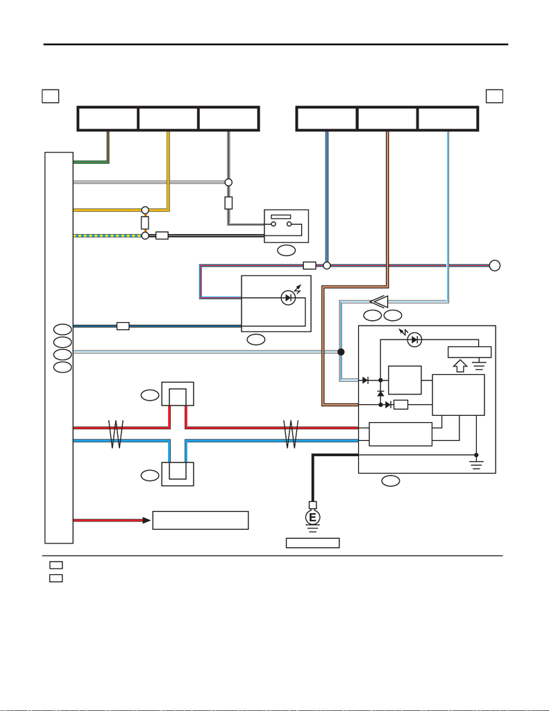

WI-271

Interior Light System

WIRING SYSTEM

28.Interior Light System

A: WIRING DIAGRAM

WI-44470

a a

1

OP

WP

OP

B555

B415

OP

3

OP

WP

OP

B281

B:

B280

A:

i84

C:

i171

D:

i10

G/RB3

G/R

Y/RA32

Y/R

A4

W/B

L/R

W/B 1

2B/W

W/BB6

B/LA25

6

B/L

20BR/W

2L/R

I/F

W/L

BR/W

40

W/L

W/L

W/LC6

W/L

33R

32L

38B

B

R

L

C27

C35

RD11

A

L/R

1

L/R

i233

i232

2

2

2

2

2

REF. TO KEYLESS ENTRY SYSTEM

[b]

MICRO

COMPUTER

DOOR

KEY

ILLUMINATION

IMMOBILIZER

ANTENNA

KEY WARNING

SWITCH

BODY

INTEGRATED UNIT

COMBINATION METER

MB-28

M/B FUSE NO. 14

(B)

MB-29

M/B FUSE NO. 8

(B)

FB-38

F/B FUSE NO. 12

(IG)

FB-29

F/B FUSE NO. 31

(ACC)

FB-12

F/B FUSE NO. 2

(IG)

FB-18

F/B FUSE NO. 7

(B)

: WITHOUT PUSH BUTTON START

: WITH PUSH BUTTON START

REF. TO GND [e]

DRIVE CIRCUIT

CAN TRANSCEIVER &

RECEIVER

POWER

SUPPLY

CIRCUIT

: WITHOUT PUSH BUTTON START : B/W

WITH PUSH BUTTON START : Y/R

J/C

J/C

: TERMINAL No. OPTIONAL ARRANGEMENT

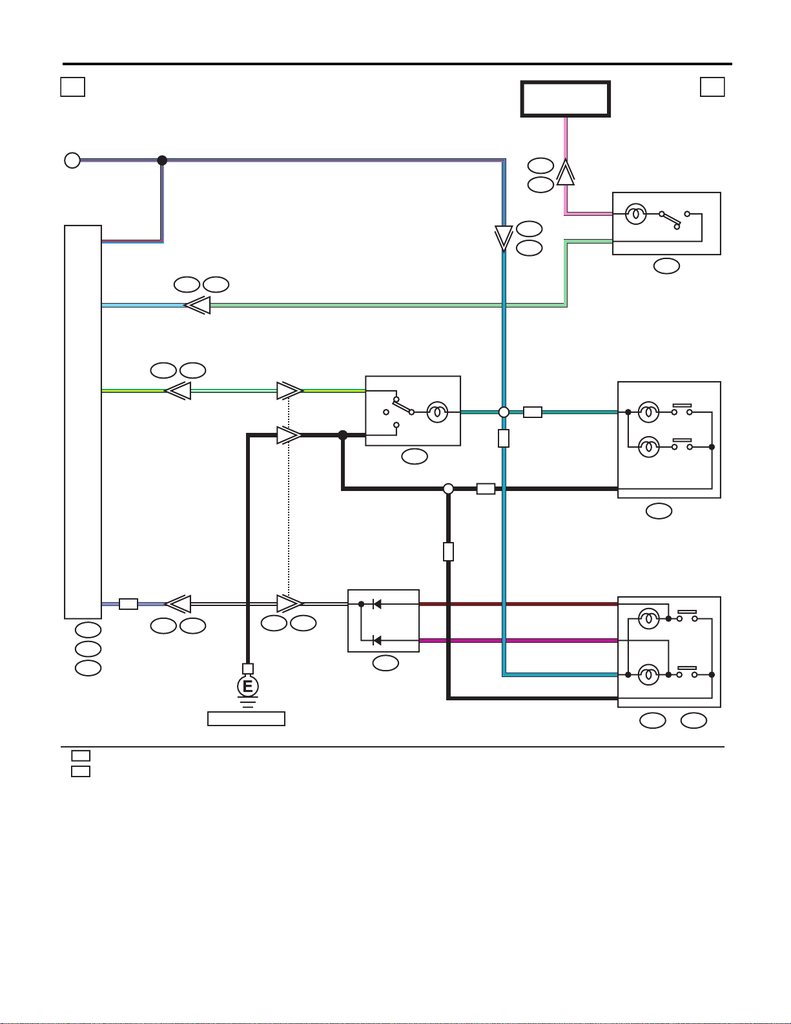

WI-272

Interior Light System

WIRING SYSTEM

WI-44471

B281

i84

i171

3

17

14

8

9

12

b b

WR

OR

B:

C:

D:

R52

R56

14

A

B90 R50

R64

R50

B90

i229 B551

i230 B552

WR

OR

WR

WR

OR

6

R81

R82

DOOR

OFF

ON

R382i195

R20

OFF

ON

3 L/G

C4

2L/G

2G/Y

B

1B

2P

1LG

LG

1

B7

B

D8 P/L

G/Y

C3 SB

L/R

L/R

L/R

G/W

B

B/W B/W 2

L/G

A1L/G

VB1

A2B

B/W

G/W

P

R/B B2

1

3

R/B

V

R56A: R62B:

TRUNK ROOM LIGHT

SPOT MAP LIGHT

SPOT MAP

LIGHT DIODE

SPOT MAP LIGHT

ROOM LIGHT

BODY

INTEGRATED UNIT

: WITHOUT SUNROOF

: WITH SUNROOF

REF. TO GND [i]

FB-11

F/B FUSE NO. 15

(B)

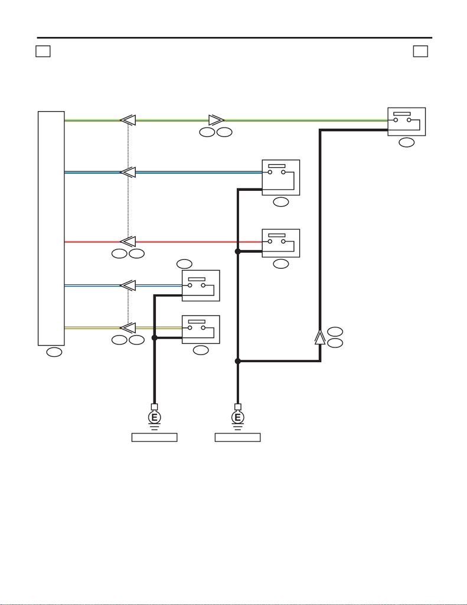

WI-273

Interior Light System

WIRING SYSTEM

WI-44472

15

16

15

16

17

1

6

c c

i84C:

R22

R9

i2 R339

R16

i195 R382

R186

R24 R60

R24

R60

R12

1

3

1

3

B

B

B

Y/W Y/W

L/W L/W

C24

C14

B

B

3

1

3

W/R W/R

L/OL/OC13

C25

C33

B

B

W/R

1L/O

Y/L

B

3

2

Y/LY/L Y/L

B

FRONT DOOR

SWITCH RH

TRUNK LID LOCK

SWITCH

REAR DOOR

SWITCH RH

FRONT DOOR

SWITCH LH

BODY

INTEGRATED UNIT

REAR DOOR

SWITCH LH

REF. TO GND [h]REF. TO GND [f]

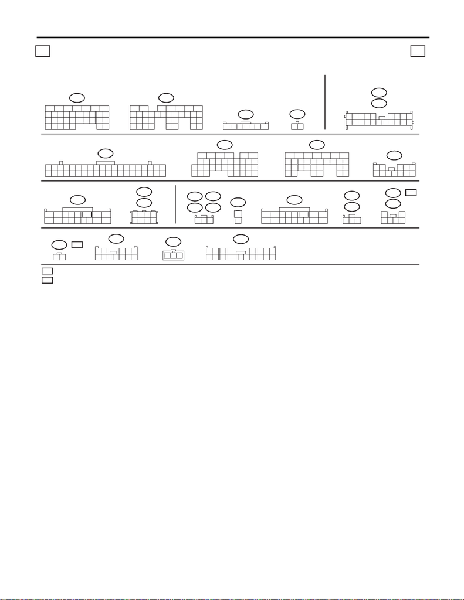

WI-274

Interior Light System

WIRING SYSTEM

21

R56A:

WR

:

OR

:

R56

5634

21

R20

(B)

2

1

i233

i232

78

5

6

34

21

OR

WR

WI-44473

d d

B280

18

2719 20 21 22

23

26

24

25

98

15

1413121110

17

16

1234567

A:

B281B:

5672134

29

10 11 12 13 14 15

2524

16

30

98

17 18 19

20

28

21 22 23

3231

26 27

33 34 35

i84C:

19

18

21

20

2322 24 25 26

17

1

23

4

56

27

28 29 30

31 32 33 34 35

798

151413121110 16

i229

12 345

6789

10 11 12

1 2345

6

7

(B)

B415

B555

12

i10

11 12

9

10

7856341

2

15 1613 14 19

18

20

21 22 23 24 26

25

17

i171D:

19

18

20 21

22

23

26

24

25

27

28 29

30 31

98

15

1413121110

17

16

1234567

i195

123

R22R12

R9

R16

R50

(GR)

10

13

345 6

14 15 16 17

1211

12 78

9

123

R52

(B)

R82

1

9

234 5678

10 11 12 14 15 16 17 18 1913

R62B:

R64

123

i230

(GR)

10

13

345 6

14 15 16 17

1211

12 78

9

R60

12 345

6789

10 11 12

i2

12345 6789

10 11 12 13 14 15 16 17 18 19 20

R186

: WITHOUT SUNROOF

: WITH SUNROOF

LIST OF CONNECTORS